Produced Tuesday 03 November 2020

**This is one page of the R Handbook for Epidemiologists, but is being printed as a stand-alone page.**

**You can find the complete handbook on [Github](https://github.com/nsbatra/Epi_R_handbook)**

# Combination analysis

## Overview

This analysis plots the frequency of different **combinations** of values/responses. In this example, we plot the frequency of symptom combinations.

This analysis is often called:  
**Multiple response analysis** **Sets analysis** **Combinations analysis**

The first method shown uses the package **ggupset**, an the second using the package **UpSetR**.

[output not shown]

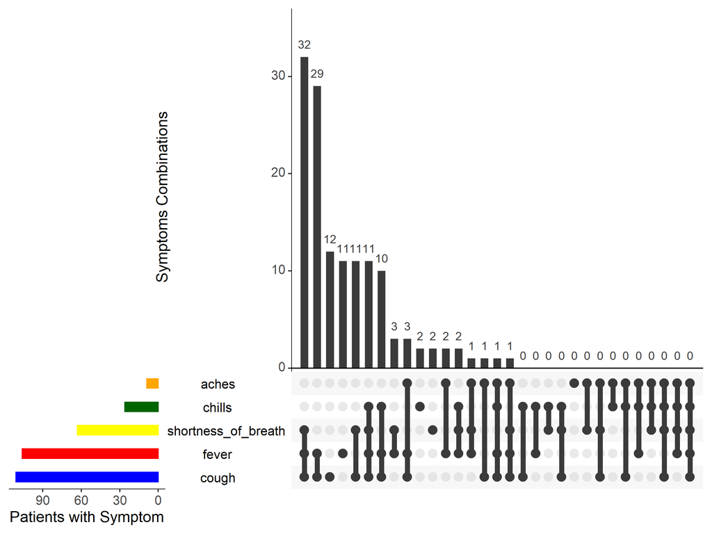

## Preparation

### View the data

This linelist includes five “yes/no” variables on reported symptoms. We will need to transform these variables a bit to use the **ggupset** package to make our plot.

View the data (scroll to the right to see the symptoms variables)

```r
DT::datatable(linelist_sym, rownames = FALSE, filter="top", options = list(pageLength = 5, scrollX=T))
```

| case_id | date_of_onset | date_of_hospitalisation | date_of_outcome | outcome | gender | age | province | fever | chills | cough | aches | shortness_of_breath |
| --- | --- | --- | --- | --- | --- | --- | --- | --- | --- | --- | --- | --- |
| 1 | 2/19/2013 |  | 3/4/2013 | Death | m | 87 | Shanghai | no | no | yes | no | no |
| 2 | 2/27/2013 | 3/3/2013 | 3/10/2013 | Death | m | 27 | Shanghai | yes | no | yes | no | yes |
| 3 | 3/9/2013 | 3/19/2013 | 4/9/2013 | Death | f | 35 | Anhui | no | yes | no | no | no |
| 4 | 3/19/2013 | 3/27/2013 |  |  | f | 45 | Jiangsu | yes | yes | yes | no | yes |
| 5 | 3/19/2013 | 3/30/2013 | 5/15/2013 | Recover | f | 48 | Jiangsu | yes | yes | yes | no | yes |
| 6 | 3/21/2013 | 3/28/2013 | 4/26/2013 | Death | f | 32 | Jiangsu | yes | no | no | no | yes |
| 7 | 3/20/2013 | 3/29/2013 | 4/9/2013 | Death | m | 83 | Jiangsu | yes | yes | yes | no | yes |
| 8 | 3/7/2013 | 3/18/2013 | 3/27/2013 | Death | m | 38 | Zhejiang | yes | yes | yes | no | yes |
| 9 | 3/25/2013 | 3/25/2013 |  |  | m | 67 | Zhejiang | yes | no | yes | no | no |
| 10 | 3/28/2013 | 4/1/2013 | 4/3/2013 | Death | m | 48 | Shanghai | yes | no | yes | no | no |

[output cut: 126 more lines]

### Re-format values

We convert the “yes” and “no the the actual symptom name. If”no", we set the value as blank.

```r
# create column with the symptoms named, separated by semicolons
linelist_sym_1 <- linelist_sym %>%

  # convert the "yes" and "no" values into the symptom name itself
  mutate(fever = case_when(fever == "yes" ~ "fever",          # if old value is "yes", new value is "fever"
                           TRUE           ~ NA_character_),   # if old value is anything other than "yes", the new value is NA

         chills = case_when(chills == "yes" ~ "chills",
                           TRUE           ~ NA_character_),

         cough = case_when(cough == "yes" ~ "cough",
                           TRUE           ~ NA_character_),

         aches = case_when(aches == "yes" ~ "aches",
                           TRUE           ~ NA_character_),

         shortness_of_breath = case_when(shortness_of_breath == "yes" ~ "shortness_of_breath",
                           TRUE           ~ NA_character_))
```

Now we make two final variables:  
1. Pasting together all the symptoms of the patient (character variable)  
2. Convert the above to class *list*, so it can be accepted by **ggupset** to make the plot

```r
linelist_sym_1 <- linelist_sym_1 %>%
  mutate(
         # combine the variables into one, using paste() with a semicolon separating any values
         all_symptoms = paste(fever, chills, cough, aches, shortness_of_breath, sep = "; "),

         # make a copy of all_symptoms variable, but of class "list" (which is required to use ggupset() in next step)
         all_symptoms_list = as.list(strsplit(all_symptoms, "; "))
         )
```

```r
DT::datatable(linelist_sym, rownames = FALSE, filter="top", options = list(pageLength = 5, scrollX=T))
```

| case_id | date_of_onset | date_of_hospitalisation | date_of_outcome | outcome | gender | age | province | fever | chills | cough | aches | shortness_of_breath |
| --- | --- | --- | --- | --- | --- | --- | --- | --- | --- | --- | --- | --- |
| 1 | 2/19/2013 |  | 3/4/2013 | Death | m | 87 | Shanghai | no | no | yes | no | no |
| 2 | 2/27/2013 | 3/3/2013 | 3/10/2013 | Death | m | 27 | Shanghai | yes | no | yes | no | yes |
| 3 | 3/9/2013 | 3/19/2013 | 4/9/2013 | Death | f | 35 | Anhui | no | yes | no | no | no |
| 4 | 3/19/2013 | 3/27/2013 |  |  | f | 45 | Jiangsu | yes | yes | yes | no | yes |
| 5 | 3/19/2013 | 3/30/2013 | 5/15/2013 | Recover | f | 48 | Jiangsu | yes | yes | yes | no | yes |
| 6 | 3/21/2013 | 3/28/2013 | 4/26/2013 | Death | f | 32 | Jiangsu | yes | no | no | no | yes |
| 7 | 3/20/2013 | 3/29/2013 | 4/9/2013 | Death | m | 83 | Jiangsu | yes | yes | yes | no | yes |
| 8 | 3/7/2013 | 3/18/2013 | 3/27/2013 | Death | m | 38 | Zhejiang | yes | yes | yes | no | yes |
| 9 | 3/25/2013 | 3/25/2013 |  |  | m | 67 | Zhejiang | yes | no | yes | no | no |
| 10 | 3/28/2013 | 4/1/2013 | 4/3/2013 | Death | m | 48 | Shanghai | yes | no | yes | no | no |

[output cut: 126 more lines]

## `ggupset`

Load required package to make the plot (**ggupset**)

```r
pacman::p_load(ggupset)
```

Create the plot:

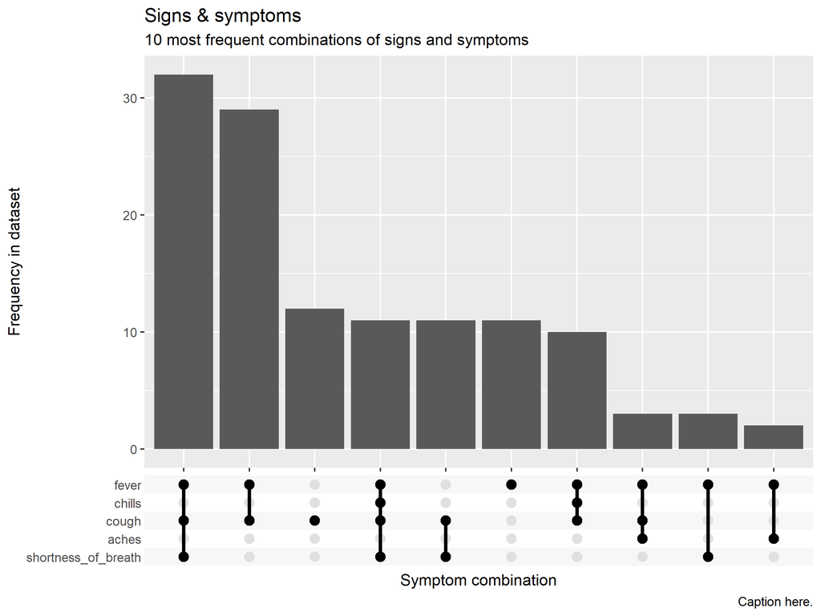

```r
ggplot(linelist_sym_1,
       aes(x=all_symptoms_list)) +
geom_bar() +
scale_x_upset(reverse = FALSE,
              n_intersections = 10,
              sets = c("fever", "chills", "cough", "aches", "shortness_of_breath")
              )+
  labs(title = "Signs & symptoms",
       subtitle = "10 most frequent combinations of signs and symptoms",
       caption = "Caption here.",
       x = "Symptom combination",
       y = "Frequency in dataset")
```

More information on **ggupset** can be found [online](https://rdrr.io/cran/ggupset/man/scale_x_upset.html) or offline in the package documentation in your RStudio Help tab.

## `UpSetR`

The **UpSetR** package allows more customization, but it more difficult to execute:

https://github.com/hms-dbmi/UpSetR *read this* https://gehlenborglab.shinyapps.io/upsetr/ *Shiny App version - you can upload your own data* https://cran.r-project.org/web/packages/UpSetR/UpSetR.pdf *documentation - difficult to interpret*

```r
pacman::p_load(UpSetR)
```

Convert symptoms variables to 1/0.

```r
# Make using upSetR

linelist_sym_2 <- linelist_sym %>%

  # convert the "yes" and "no" values into the symptom name itself
  mutate(fever = case_when(fever == "yes" ~ 1,          # if old value is "yes", new value is "fever"
                           TRUE           ~ 0),   # if old value is anything other than "yes", the new value is NA

         chills = case_when(chills == "yes" ~ 1,
                           TRUE           ~ 0),

         cough = case_when(cough == "yes" ~ 1,
                           TRUE           ~ 0),

         aches = case_when(aches == "yes" ~ 1,
                           TRUE           ~ 0),

         shortness_of_breath = case_when(shortness_of_breath == "yes" ~ 1,
                           TRUE           ~ 0))
```

Now make the plot, using only the symptom variables. Must designate which “sets” to compare (the names of the symptom variables).  
Alternatively use `nsets =` and `order.by = "freq"` to only show the top X combinations.

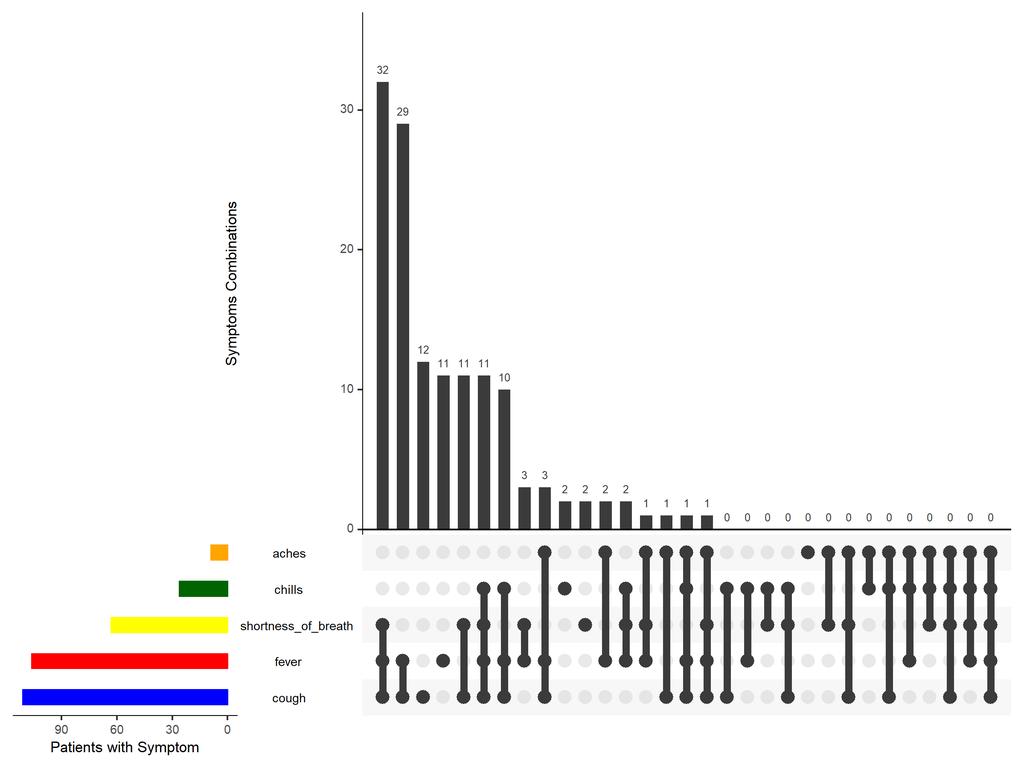

```r
# Make the plot
UpSetR::upset(
  select(linelist_sym_2, fever, chills, cough, aches, shortness_of_breath),
  sets = c("fever", "chills", "cough", "aches", "shortness_of_breath"),
  order.by = "freq",
  sets.bar.color = c("blue", "red", "yellow", "darkgreen", "orange"), # optional colors
  empty.intersections = "on",
  # nsets = 3,
  number.angles = 0,
  point.size = 3.5,
  line.size = 2,
  mainbar.y.label = "Symptoms Combinations",
  sets.x.label = "Patients with Symptom")
```